# Epistasis analysis of CssS-recovered set in LB-pH5 media

Kenyon

June 25, 2016

### Describe dataset

Regenerated CssS strain set grown on LB acidified to pH5 with HCl

Strain set consists of single-gene deletion strains:

- AM373: Reference strain; no deletions
- [cssS:](http://subtiwiki.uni-goettingen.de/bank/index.php?gene=cssS&action=Go) two-component sensor kinase gene that response to secretion stress deleted
- [mcpA:](http://subtiwiki.uni-goettingen.de/bank/index.php?gene=mcpA&action=Go) membrane-bound chemotaxis receptor gene deleted
- [nhaK:](http://subtiwiki.uni-goettingen.de/bank/index.php?gene=nhaK&action=Go) cation/H+ antiporter gene deleted

Double-gene deletion strains:

- CM : cssS/mcpA double KO strain
- CN : cssS/nhaK KO
- MN : mcpA/nhaK KO

### 1. Import growth rate measurement files

```r
#Import growth curve data file:
gcfile<-read.csv("C:/Users/Kenyon/Documents/Bacillus_subtilis/Growth Rates/Eon data/LB+HCL-PH5/LB_pH5-gcfit-repsavgd2016-06-14.csv",row.names=1)
gcfile<-gcfile[,-1]

#text variables:
media<-"LB_pH5"
strain_order<-c("AM373","CssS","McpA","NhaK","CM","CN","MN")

library(knitr)
library(dplyr)
library(tidyr)
```

### 2. Reshape to create stacked version of data

### 3. Plots of raw measurements by strain:

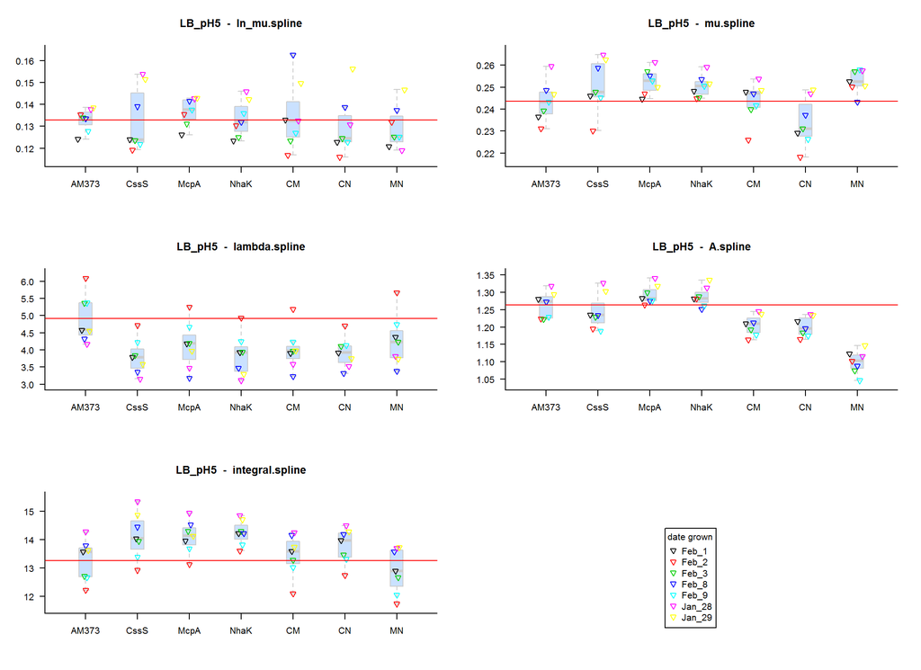

```
## [1] "units on y-axis of figures:  lambda.spline (hrs), ln_mu.spline (ln(OD)/hr), A.spline (OD600), integral.spline (OD*hrs)"
```

### 4. Normalization

#### a. Normalize data by experiment (plate) average

**average normalized values of each assay, by strain:**

| assay | num | AM373 | CssS | McpA | NhaK | CM | CN | MN | power |
| --- | --- | --- | --- | --- | --- | --- | --- | --- | --- |
| lambda.spline | 7 | 1.193 | 0.923 | 0.997 | 0.930 | 0.972 | 0.953 | 1.033 | 0.0671 |
| A.spline | 7 | 1.029 | 1.014 | 1.054 | 1.049 | 0.982 | 0.978 | 0.895 | 0.0210 |
| ln_mu.spline | 7 | 1.002 | 1.000 | 1.029 | 1.005 | 1.013 | 0.977 | 0.974 | 0.0858 |
| mu.spline | 7 | 0.987 | 1.015 | 1.024 | 1.015 | 0.987 | 0.948 | 1.025 | 0.0335 |
| integral.spline | 7 | 0.968 | 1.031 | 1.030 | 1.041 | 0.982 | 1.006 | 0.942 | 0.0267 |

**%-differences of each strain from AM373:**

| assay | num | CssS | McpA | NhaK | CM | CN | MN | avg_sd | power |
| --- | --- | --- | --- | --- | --- | --- | --- | --- | --- |
| lambda.spline | 7 | -0.226 | -0.164 | -0.220 | -0.185 | -0.201 | -0.134 | 0.034 | 0.042 |
| A.spline | 7 | -0.015 | 0.024 | 0.019 | -0.046 | -0.050 | -0.130 | 0.013 | 0.016 |
| ln_mu.spline | 7 | -0.002 | 0.027 | 0.003 | 0.011 | -0.025 | -0.028 | 0.052 | 0.068 |
| mu.spline | 7 | 0.028 | 0.037 | 0.028 | 0.000 | -0.040 | 0.039 | 0.021 | 0.028 |
| integral.spline | 7 | 0.065 | 0.064 | 0.075 | 0.014 | 0.039 | -0.027 | 0.017 | 0.022 |

**%-differences, if above experiment-power:**

| assay | num | CssS | McpA | NhaK | CM | CN | MN | power |
| --- | --- | --- | --- | --- | --- | --- | --- | --- |
| lambda.spline | 7 | -0.226 | -0.164 | -0.220 | -0.185 | -0.201 | -0.134 | 0.042 |
| A.spline | 7 |  | 0.024 | 0.019 | -0.046 | -0.050 | -0.130 | 0.016 |
| ln_mu.spline | 7 |  |  |  |  |  |  | 0.068 |
| mu.spline | 7 | 0.028 | 0.037 | 0.028 |  | -0.040 | 0.039 | 0.028 |
| integral.spline | 7 | 0.065 | 0.064 | 0.075 |  | 0.039 | -0.027 | 0.022 |

- power calculation is based on alpha=0.05, beta=0.2, paired measurements

#### b. Normalized all measurements by dividing each value by avg AM373 value for that measurement

After normalization, a new parameter is also generated - euclidian distance across the growth rate features `eucld_dist = sqrt((lambda.spline^2)+(A.spline^2)+(mu.spline^2)+(ln_mu.spline^2)+(integral.spline^2))`

Estimated phenotype of the double mutants is also calculated at this stage, named “XX_est”, and plotted in orange next to the measured phenotype of each double mutant (dark blue)

The est-double mutant phenotype is the sum of the effects of the single mutants in each replicate experiment -  
ie, `(sing1 - AM373) + (sing2 - AM373)`

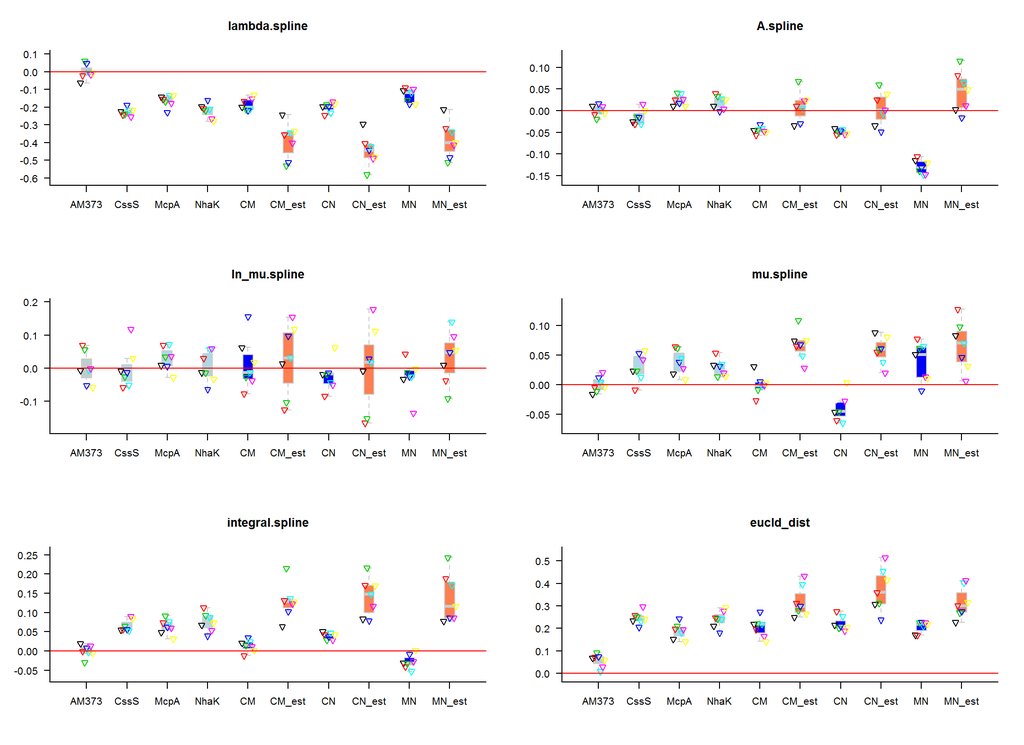

### 5. Identify Epistatic Interactions

Calculate estimated value of double mutants from the single mutants, and whether the measure phenotypes of the double mutants are sig dif from that estimate

In the t-box plots, looking for features in which the measured double-mutant phenotype (dark blue) is well-separated from the estimated phenotype (orange)

**Two Epistasis Calculation Methods:**

**Linear Modeling Results:** Identify epistasis using linear modeling to identify significant interaction effects * in printed output, the double-mutant column (ie, “CM”) is not the % dif from AM373-avg, but is the difference between double-mutant observed and double-estimated phenotype (ie, CM - CMest in the second table)

**Estimated Phenotype Calculation Results:** Calcuate epistasis using t.test between observed and estimated double-mutant phenotype

## CM:

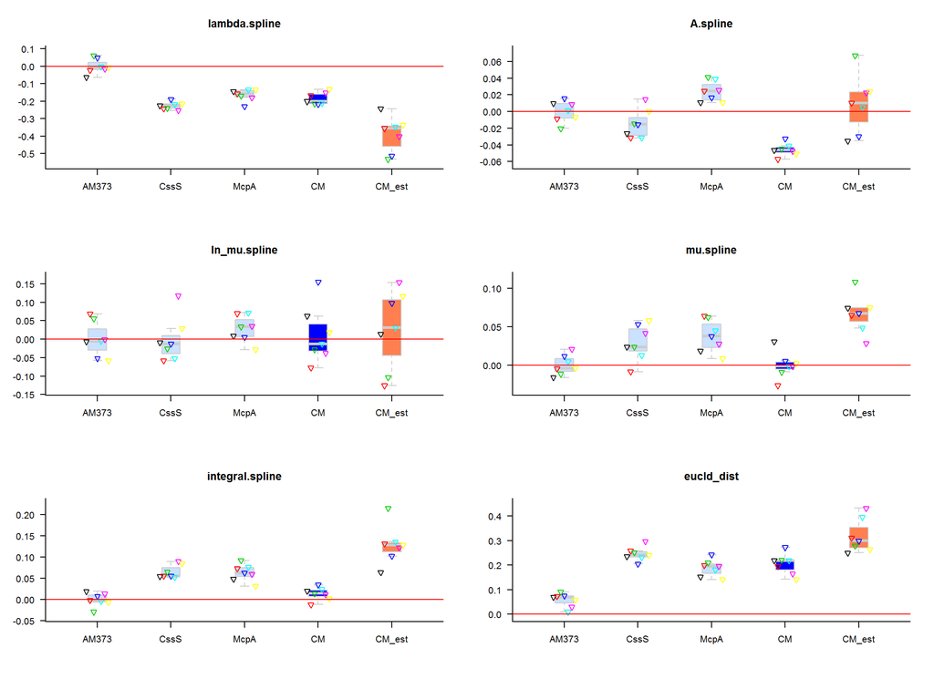

```
## [1] "Linear Modeling Results:"
```

```
##   col            meas    AM373   CssS  McpA     CM p-CMinter
## 1   6   lambda.spline   -1e-16  -0.23 -0.16    0.2   3.3e-08
## 2   7        A.spline -4.5e-17 -0.015 0.024 -0.055   8.7e-06
## 3   9       mu.spline -5.2e-18  0.029 0.038 -0.067   0.00011
## 4  10 integral.spline  6.3e-17  0.065 0.063  -0.11     3e-09
## 5  11      eucld_dist    0.058   0.19  0.13  -0.17   6.3e-07
```

```
## [1] "Estimated Phenotype Calculation Results:"
```

```
##             assay  media     CssS    McpA        CM   CM_est  t.test wil.test sig
## 1   lambda.spline LB_pH5 -0.22600 -0.1640 -0.185000 -0.39000 0.00131   0.0156   *
## 2        A.spline LB_pH5 -0.01490  0.0240 -0.045700  0.00916 0.00893   0.0156   *
## 3    ln_mu.spline LB_pH5 -0.00171  0.0279  0.011600  0.02620 0.71300   1.0000
## 4       mu.spline LB_pH5  0.02910  0.0376 -0.000145  0.06670 0.00108   0.0156   *
## 5 integral.spline LB_pH5  0.06510  0.0631  0.013600  0.12800 0.00102   0.0156   *
## 6      eucld_dist LB_pH5  0.24500  0.1880  0.204000  0.31800 0.01320   0.0156   *
```

## CN:

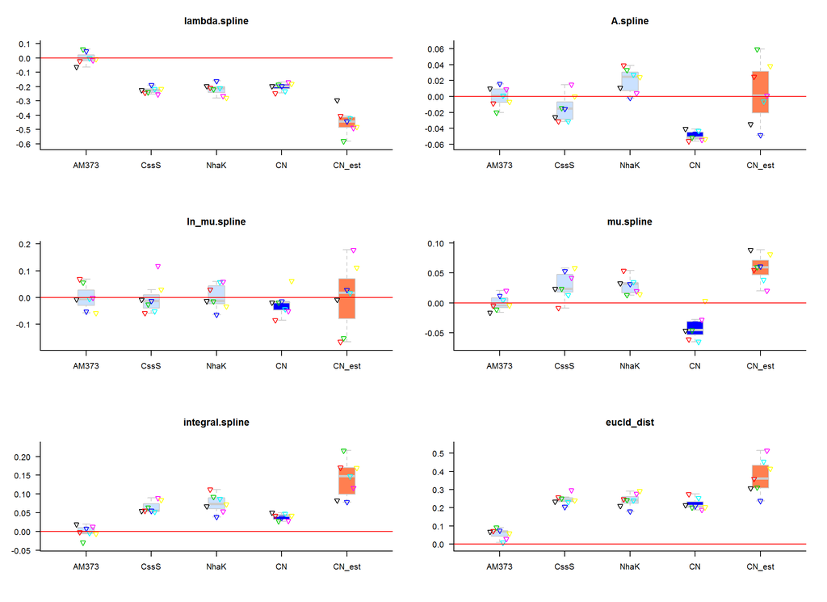

```
##   col            meas    AM373   CssS  NhaK     CN p-CNinter
## 1   6   lambda.spline -2.1e-17  -0.23 -0.22   0.24   1.4e-09
## 2   7        A.spline -5.4e-17 -0.015  0.02 -0.054   1.9e-05
## 3   9       mu.spline -1.8e-17  0.029 0.029 -0.097   5.8e-07
## 4  10 integral.spline  5.8e-17  0.065 0.075   -0.1   5.3e-08
## 5  11      eucld_dist    0.058   0.19  0.18  -0.21   7.7e-09
```

```
##             assay  media     CssS     NhaK      CN   CN_est   t.test wil.test sig
## 1   lambda.spline LB_pH5 -0.22600 -0.22000 -0.2010 -0.44600 7.40e-04   0.0156   *
## 2        A.spline LB_pH5 -0.01490  0.01960 -0.0495  0.00472 1.58e-02   0.0312   *
## 3    ln_mu.spline LB_pH5 -0.00171  0.00307 -0.0241  0.00136 5.81e-01   0.6880
## 4       mu.spline LB_pH5  0.02910  0.02860 -0.0396  0.05770 8.98e-05   0.0156   *
## 5 integral.spline LB_pH5  0.06510  0.07500  0.0392  0.14000 2.55e-03   0.0156   *
## 6      eucld_dist LB_pH5  0.24500  0.24100  0.2210  0.37100 7.69e-03   0.0156   *
```

## MN:

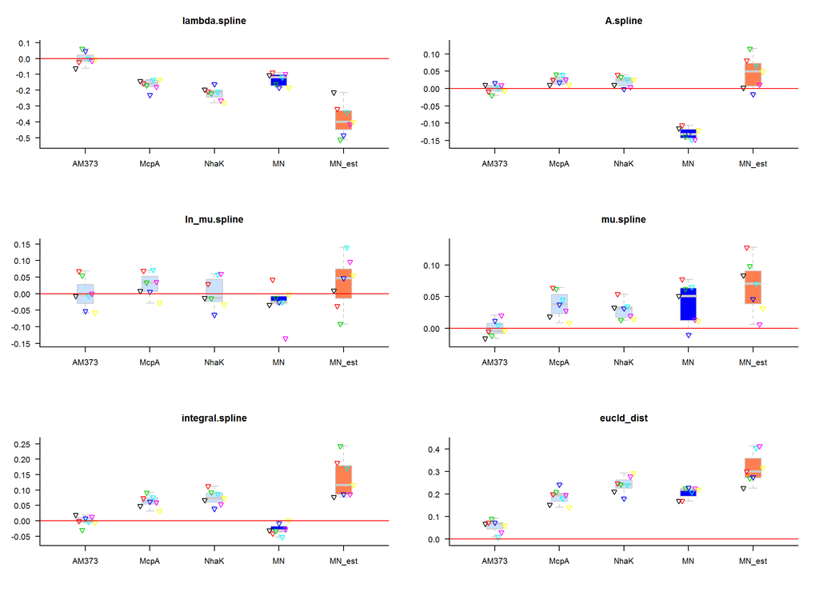

```
##   col            meas    AM373  McpA  NhaK    MN p-MNinter
## 1   6   lambda.spline -5.2e-17 -0.16 -0.22  0.25   1.4e-08
## 2   7        A.spline -4.5e-17 0.024  0.02 -0.17   2.3e-14
## 3  10 integral.spline  6.8e-17 0.063 0.075 -0.17   8.4e-11
## 4  11      eucld_dist    0.058  0.13  0.18 -0.17   4.3e-07
```

```
##             assay  media    McpA     NhaK      MN  MN_est   t.test wil.test sig
## 1   lambda.spline LB_pH5 -0.1640 -0.22000 -0.1340 -0.3840 1.85e-04   0.0156   *
## 2        A.spline LB_pH5  0.0240  0.01960 -0.1300  0.0436 9.39e-05   0.0156   *
## 3    ln_mu.spline LB_pH5  0.0279  0.00307 -0.0276  0.0310 2.28e-01   0.4690
## 4       mu.spline LB_pH5  0.0376  0.02860  0.0385  0.0662 1.96e-02   0.0469   *
## 5 integral.spline LB_pH5  0.0631  0.07500 -0.0276  0.1380 1.06e-03   0.0156   *
## 6      eucld_dist LB_pH5  0.1880  0.24100  0.2070  0.3140 4.39e-03   0.0156   *
```

### Summary:

Significant evidence of epistasis found in all three double-mutants, across multiple growth curve parameters. Only parameter without apparent epistasis in any strain is ln_mu.spline (max GR in ln-transformed growth curve)